# Udacity Project : Wrangle and Analyze Data

### Tidiness

#### 4- `archive` : Same source

##### Define

All tweets have almost the same source value : we don't need this variable --> we will remove it

##### Code

```python
archive_clean.drop('source', axis=1, inplace=True)
```

##### Test

```python
# Confirm source column is gone
'source' not in archive_clean.columns
```

```
True
```

```python
archive_clean.info()
```

```
<class 'pandas.core.frame.DataFrame'>
Int64Index: 2175 entries, 0 to 2355
Data columns (total 10 columns):
 #   Column              Non-Null Count  Dtype
---  ------              --------------  -----
 0   tweet_id            2175 non-null   int64
 1   timestamp           2175 non-null   object
 2   text                2175 non-null   object
 3   rating_numerator    2175 non-null   int64
 4   rating_denominator  2175 non-null   int64
 5   name                2175 non-null   object
 6   doggo               2175 non-null   object
 7   floofer             2175 non-null   object
 8   pupper              2175 non-null   object
 9   puppo               2175 non-null   object
dtypes: int64(3), object(7)
memory usage: 186.9+ KB
```

#### 5- `archive` : One variable dog stage in four columns (doggo, floofer, pupper & puppo )

##### Define

- Melt the **doggo**, **floofer**, **pupper** & **puppo** columns to a **stage_col** and a **stage** column.
- Then keep only rows that have at least one dog stage (**stage_col** = **stage**) or no stage(**None** in four columns)
- Drop **stage_col** column

##### Code

```python
#melt the doggo, floofer, pupper & puppo columns to a stage_col and a stage column
archive_clean = pd.melt(archive_clean, id_vars=['tweet_id', 'timestamp', 'text', 'rating_numerator', 'rating_denominator', 'name'], var_name='stage_col' , value_name='stage' )

# each tweet_id has four duplicated rows
# we will keep only one row four each tweet_id

# tweet_id of tweets with dog stage
tweet_id_stage = archive_clean.query('stage_col == stage')['tweet_id'].values
# index of duplicated rows of tweets with dog stage
tweet_stage_none_index = archive_clean[(archive_clean['tweet_id'].isin(tweet_id_stage)) & (archive_clean['stage'] == 'None')].index
# drop these duplicated rows
archive_clean.drop(tweet_stage_none_index, axis=0, inplace=True)

#Drop stage_col column
archive_clean.drop('stage_col', axis=1, inplace=True)

# drop duplicated rows of tweets without dog stage
archive_clean.drop_duplicates(inplace=True)
```

##### Test

```python
archive_clean.shape
```

```
(2187, 7)
```

```python
# print rows with more than one different stage
archive_clean[archive_clean.duplicated('tweet_id',keep=False)][['tweet_id','text','stage']].sort_values('tweet_id')
```

|  | tweet_id | text | stage |
| --- | --- | --- | --- |
| 935 | 733109485275860992 | Like father (doggo), like son (pupper). Both 12/10 https://t.co/pG2inLaOda | doggo |
| 5285 | 733109485275860992 | Like father (doggo), like son (pupper). Both 12/10 https://t.co/pG2inLaOda | pupper |
| 885 | 741067306818797568 | This is just downright precious af. 12/10 for both pupper and doggo https://t.co/o5J479bZUC | doggo |
| 5235 | 741067306818797568 | This is just downright precious af. 12/10 for both pupper and doggo https://t.co/o5J479bZUC | pupper |
| 781 | 751583847268179968 | Please stop sending it pictures that don't even have a doggo or pupper in them. Churlish af. 5/10 neat couch tho https://t.co/u2c9c7qSg8 | doggo |
| 5131 | 751583847268179968 | Please stop sending it pictures that don't even have a doggo or pupper in them. Churlish af. 5/10 neat couch tho https://t.co/u2c9c7qSg8 | pupper |
| 722 | 759793422261743616 | Meet Maggie &amp; Lila. Maggie is the doggo, Lila is the pupper. They are sisters. Both 12/10 would pet at the same time https://t.co/MYwR4DQKll | doggo |
| 5072 | 759793422261743616 | Meet Maggie &amp; Lila. Maggie is the doggo, Lila is the pupper. They are sisters. Both 12/10 would pet at the same time https://t.co/MYwR4DQKll | pupper |
| 593 | 781308096455073793 | Pupper butt 1, Doggo 0. Both 12/10 https://t.co/WQvcPEpH2u | doggo |
| 4943 | 781308096455073793 | Pupper butt 1, Doggo 0. Both 12/10 https://t.co/WQvcPEpH2u | pupper |
| 567 | 785639753186217984 | This is Pinot. He's a sophisticated doggo. You can tell by the hat. Also pointier than your average pupper. Still 10/10 would pet cautiously https://t.co/f2wmLZTPHd | doggo |
| 4917 | 785639753186217984 | This is Pinot. He's a sophisticated doggo. You can tell by the hat. Also pointier than your average pupper. Still 10/10 would pet cautiously https://t.co/f2wmLZTPHd | pupper |
| 474 | 801115127852503040 | This is Bones. He's being haunted by another doggo of roughly the same size. 12/10 deep breaths pupper everything's fine https://t.co/55Dqe0SJNj | doggo |
| 4824 | 801115127852503040 | This is Bones. He's being haunted by another doggo of roughly the same size. 12/10 deep breaths pupper everything's fine https://t.co/55Dqe0SJNj | pupper |
| 467 | 802265048156610565 | Like doggo, like pupper version 2. Both 11/10 https://t.co/9IxWAXFqze | doggo |
| 4817 | 802265048156610565 | Like doggo, like pupper version 2. Both 11/10 https://t.co/9IxWAXFqze | pupper |
| 442 | 808106460588765185 | Here we have Burke (pupper) and Dexter (doggo). Pupper wants to be exactly like doggo. Both 12/10 would pet at same time https://t.co/ANBpEYHaho | doggo |
| 4792 | 808106460588765185 | Here we have Burke (pupper) and Dexter (doggo). Pupper wants to be exactly like doggo. Both 12/10 would pet at same time https://t.co/ANBpEYHaho | pupper |
| 4732 | 817777686764523521 | This is Dido. She's playing the lead role in "Pupper Stops to Catch Snow Before Resuming Shadow Box with Dried Apple." 13/10 (IG: didodoggo) https://t.co/m7isZrOBX7 | pupper |
| 382 | 817777686764523521 | This is Dido. She's playing the lead role in "Pupper Stops to Catch Snow Before Resuming Shadow Box with Dried Apple." 13/10 (IG: didodoggo) https://t.co/m7isZrOBX7 | doggo |
| 172 | 854010172552949760 | At first I thought this was a shy doggo, but it's actually a Rare Canadian Floofer Owl. Amateurs would confuse the two. 11/10 only send dogs https://t.co/TXdT3tmuYk | doggo |
| 2347 | 854010172552949760 | At first I thought this was a shy doggo, but it's actually a Rare Canadian Floofer Owl. Amateurs would confuse the two. 11/10 only send dogs https://t.co/TXdT3tmuYk | floofer |
| 165 | 855851453814013952 | Here's a puppo participating in the #ScienceMarch. Cleverly disguising her own doggo agenda. 13/10 would keep the planet habitable for https://t.co/cMhq16isel | doggo |
| 6690 | 855851453814013952 | Here's a puppo participating in the #ScienceMarch. Cleverly disguising her own doggo agenda. 13/10 would keep the planet habitable for https://t.co/cMhq16isel | puppo |

#### 6- `archive` : rows with more than one different stage

##### Define

- Remove rows that have more than one different stage

##### Code

```python
archive_clean.drop_duplicates('tweet_id',keep=False, inplace=True)
```

##### Test

```python
archive_clean.info()
```

```
<class 'pandas.core.frame.DataFrame'>
Int64Index: 2163 entries, 0 to 7430
Data columns (total 7 columns):
 #   Column              Non-Null Count  Dtype
---  ------              --------------  -----
 0   tweet_id            2163 non-null   int64
 1   timestamp           2163 non-null   object
 2   text                2163 non-null   object
 3   rating_numerator    2163 non-null   int64
 4   rating_denominator  2163 non-null   int64
 5   name                2163 non-null   object
 6   stage               2163 non-null   object
dtypes: int64(3), object(4)
memory usage: 135.2+ KB
```

#### 7- `images` : dog breed prediction should be in one column

##### define

- Create new column **breed**
- **breed** column will take only predictions that are breed ( in case many values, take the first one)
- Rows without breed prediction will be dropped
- Columns [p1', 'p1_conf', 'p1_dog', 'p2','p2_conf', 'p2_dog', 'p3', 'p3_conf', 'p3_dog'] will be also dopped

##### Code

```python
#Create new column breed
images_clean['breed'] = ''
```

```python
#fill breed column
for index in images_clean.index :
    if images_clean.loc[index, 'p1_dog'] :
        images_clean.loc[index, 'breed'] = images_clean.loc[index, 'p1']
    elif images_clean.loc[index, 'p2_dog'] :
        images_clean.loc[index, 'breed'] = images_clean.loc[index, 'p2']
    elif images_clean.loc[index, 'p3_dog'] :
        images_clean.loc[index, 'breed'] = images_clean.loc[index, 'p3']
    else:
        images_clean.loc[index, 'breed'] = None
```

```python
#drop nan values
images_clean.dropna(inplace=True)
```

```python
# drop columns :
images_clean.drop(['p1', 'p1_conf', 'p1_dog', 'p2','p2_conf', 'p2_dog', 'p3', 'p3_conf', 'p3_dog'], axis=1, inplace=True)
```

##### Test

```python
images_clean.info()
```

```
<class 'pandas.core.frame.DataFrame'>
Int64Index: 1751 entries, 0 to 2073
Data columns (total 4 columns):
 #   Column    Non-Null Count  Dtype
---  ------    --------------  -----
 0   tweet_id  1751 non-null   int64
 1   jpg_url   1751 non-null   object
 2   img_num   1751 non-null   int64
 3   breed     1751 non-null   object
dtypes: int64(2), object(2)
memory usage: 68.4+ KB
```

```python
images_clean.sample(10)
```

|  | tweet_id | jpg_url | img_num | breed |
| --- | --- | --- | --- | --- |
| 1923 | 857029823797047296 | https://pbs.twimg.com/media/C-TIEwMW0AEjb55.jpg | 2 | golden_retriever |
| 737 | 687109925361856513 | https://pbs.twimg.com/media/CYka1NTWMAAOclP.jpg | 2 | borzoi |
| 1231 | 745789745784041472 | https://pbs.twimg.com/media/ClmT0KHWkAAXbhy.jpg | 1 | Pekinese |
| 1745 | 822975315408461824 | https://pbs.twimg.com/media/C2vLrpvWIAA3LM3.jpg | 1 | Pembroke |
| 1170 | 736225175608430592 | https://pbs.twimg.com/media/CjeY5DKXEAA3WkD.jpg | 1 | Labrador_retriever |
| 860 | 696900204696625153 | https://pbs.twimg.com/media/CavjCdJW0AIB5Oz.jpg | 1 | Chihuahua |
| 282 | 671134062904504320 | https://pbs.twimg.com/media/CVBY3e7XIAAAE4Y.jpg | 1 | Shih-Tzu |
| 1115 | 724983749226668032 | https://pbs.twimg.com/media/Cg-o3w0WgAANXdv.jpg | 1 | golden_retriever |
| 2043 | 885984800019947520 | https://pbs.twimg.com/media/DEumeWWV0AA-Z61.jpg | 1 | Blenheim_spaniel |
| 1261 | 748932637671223296 | https://pbs.twimg.com/media/CmS-QkQWAAAkUa-.jpg | 1 | borzoi |

#### 8- `All tables` : Merge all tables

##### Define

- Merge all three tables in one table on tweet_id (Primary key)

##### Code

```python
#merge archive table with tweets table
archive_clean = pd.merge(archive_clean, tweets_clean, on='tweet_id')
#merge archive table with images table
archive_clean = pd.merge(archive_clean, images_clean, on='tweet_id')
```

##### Test

```python
archive_clean.head()
```

|  | tweet_id | timestamp | text | rating_numerator | rating_denominator | name | stage | retweet_count | favorite_count | expanded_urls | jpg_url | img_num | breed |
| --- | --- | --- | --- | --- | --- | --- | --- | --- | --- | --- | --- | --- | --- |
| 0 | 892177421306343426 | 2017-08-01 00:17:27 +0000 | This is Tilly. She's just checking pup on you. Hopes you're doing ok. If not, she's available for pats, snugs, boops, the whole bit. 13/10 https://t.co/0Xxu71qeIV | 13 | 10 | Tilly | None | 5434 | 30088 | https://twitter.com/dog_rates/status/892177421306343426/photo/1 | https://pbs.twimg.com/media/DGGmoV4XsAAUL6n.jpg | 1 | Chihuahua |
| 1 | 891815181378084864 | 2017-07-31 00:18:03 +0000 | This is Archie. He is a rare Norwegian Pouncing Corgo. Lives in the tall grass. You never know when one may strike. 12/10 https://t.co/wUnZnhtVJB | 12 | 10 | Archie | None | 3584 | 22641 | https://twitter.com/dog_rates/status/891815181378084864/photo/1 | https://pbs.twimg.com/media/DGBdLU1WsAANxJ9.jpg | 1 | Chihuahua |
| 2 | 891689557279858688 | 2017-07-30 15:58:51 +0000 | This is Darla. She commenced a snooze mid meal. 13/10 happens to the best of us https://t.co/tD36da7qLQ | 13 | 10 | Darla | None | 7466 | 37997 | https://twitter.com/dog_rates/status/891689557279858688/photo/1 | https://pbs.twimg.com/media/DF_q7IAWsAEuuN8.jpg | 1 | Labrador_retriever |
| 3 | 891327558926688256 | 2017-07-29 16:00:24 +0000 | This is Franklin. He would like you to stop calling him "cute." He is a very fierce shark and should be respected as such. 12/10 #BarkWeek https://t.co/AtUZn91f7f | 12 | 10 | Franklin | None | 8020 | 36278 | https://twitter.com/dog_rates/status/891327558926688256/photo/1 | https://pbs.twimg.com/media/DF6hr6BUMAAzZgT.jpg | 2 | basset |
| 4 | 891087950875897856 | 2017-07-29 00:08:17 +0000 | Here we have a majestic great white breaching off South Africa's coast. Absolutely h*ckin breathtaking. 13/10 (IG: tucker_marlo) #BarkWeek https://t.co/kQ04fDDRmh | 13 | 10 | None | None | 2688 | 18293 | https://twitter.com/dog_rates/status/891087950875897856/photo/1 | https://pbs.twimg.com/media/DF3HwyEWsAABqE6.jpg | 1 | Chesapeake_Bay_retriever |

```python
archive_clean.info()
```

```
<class 'pandas.core.frame.DataFrame'>
Int64Index: 1669 entries, 0 to 1668
Data columns (total 13 columns):
 #   Column              Non-Null Count  Dtype
---  ------              --------------  -----
 0   tweet_id            1669 non-null   int64
 1   timestamp           1669 non-null   object
 2   text                1669 non-null   object
 3   rating_numerator    1669 non-null   int64
 4   rating_denominator  1669 non-null   int64
 5   name                1669 non-null   object
 6   stage               1669 non-null   object
 7   retweet_count       1669 non-null   int64
 8   favorite_count      1669 non-null   int64
 9   expanded_urls       1669 non-null   object
 10  jpg_url             1669 non-null   object
 11  img_num             1669 non-null   int64
 12  breed               1669 non-null   object
dtypes: int64(6), object(7)
memory usage: 182.5+ KB
```

### Quality

#### 9- Erroneous datatypes : `timestamp`

##### Define

- Convert the `timestamp` column's data type from a string to a datetime using **pandas.to_datetime()**

##### Code

```python
archive_clean['timestamp'] = pd.to_datetime(archive_clean['timestamp'])
```

##### Test

```python
archive_clean['timestamp'].dtypes
```

```
datetime64[ns, UTC]
```

#### 10- Erroneous datatypes : `tweet_id`

##### Define

- Convert the `tweet_id` column's data type from a integer to a string using **astype()**

##### Code

```python
archive_clean['tweet_id'] = archive_clean['tweet_id'].astype(str)
```

##### Test

```python
archive_clean['tweet_id'].dtypes
```

```
dtype('O')
```

#### 11- Inaccurate Data : `rating_numerator` & `rating_denominator`

a- tweets have Wrong rating like 24/7

b- tweets don't have the right rating (9/11 instead of 14/10)

c- tweets don't have the right format like 165/150

d- some tweets have rating_numerator as float type

e- rating_numerator < 10

```python
archive_clean.query('rating_denominator != 10')[['tweet_id', 'text','rating_numerator', 'rating_denominator']]
```

|  | tweet_id | text | rating_numerator | rating_denominator |
| --- | --- | --- | --- | --- |
| 258 | 820690176645140481 | The floofs have been released I repeat the floofs have been released. 84/70 https://t.co/NIYC820tmd | 84 | 70 |
| 309 | 810984652412424192 | Meet Sam. She smiles 24/7 &amp; secretly aspires to be a reindeer. \nKeep Sam smiling by clicking and sharing this link:\nhttps://t.co/98tB8y7y7t https://t.co/LouL5vdvxx | 24 | 7 |
| 531 | 758467244762497024 | Why does this never happen at my front door... 165/150 https://t.co/HmwrdfEfUE | 165 | 150 |
| 627 | 740373189193256964 | After so many requests, this is Bretagne. She was the last surviving 9/11 search dog, and our second ever 14/10. RIP https://t.co/XAVDNDaVgQ | 9 | 11 |
| 692 | 722974582966214656 | Happy 4/20 from the squad! 13/10 for all https://t.co/eV1diwds8a | 4 | 20 |
| 720 | 716439118184652801 | This is Bluebert. He just saw that both #FinalFur match ups are split 50/50. Amazed af. 11/10 https://t.co/Kky1DPG4iq | 50 | 50 |
| 739 | 713900603437621249 | Happy Saturday here's 9 puppers on a bench. 99/90 good work everybody https://t.co/mpvaVxKmc1 | 99 | 90 |
| 757 | 710658690886586372 | Here's a brigade of puppers. All look very prepared for whatever happens next. 80/80 https://t.co/0eb7R1Om12 | 80 | 80 |
| 773 | 709198395643068416 | From left to right:\nCletus, Jerome, Alejandro, Burp, &amp; Titson\nNone know where camera is. 45/50 would hug all at once https://t.co/sedre1ivTK | 45 | 50 |
| 823 | 704054845121142784 | Here is a whole flock of puppers. 60/50 I'll take the lot https://t.co/9dpcw6MdWa | 60 | 50 |
| 877 | 697463031882764288 | Happy Wednesday here's a bucket of pups. 44/40 would pet all at once https://t.co/HppvrYuamZ | 44 | 40 |
| 990 | 684225744407494656 | Two sneaky puppers were not initially seen, moving the rating to 143/130. Please forgive us. Thank you https://t.co/kRK51Y5ac3 | 143 | 130 |
| 991 | 684222868335505415 | Someone help the girl is being mugged. Several are distracting her while two steal her shoes. Clever puppers 121/110 https://t.co/1zfnTJLt55 | 121 | 110 |
| 1007 | 682962037429899265 | This is Darrel. He just robbed a 7/11 and is in a high speed police chase. Was just spotted by the helicopter 10/10 https://t.co/7EsP8LmSp5 | 7 | 11 |
| 1076 | 677716515794329600 | IT'S PUPPERGEDDON. Total of 144/120 ...I think https://t.co/ZanVtAtvIq | 144 | 120 |
| 1116 | 675853064436391936 | Here we have an entire platoon of puppers. Total score: 88/80 would pet all at once https://t.co/y93p6FLvVw | 88 | 80 |
| 1455 | 666287406224695296 | This is an Albanian 3 1/2 legged Episcopalian. Loves well-polished hardwood flooring. Penis on the collar. 9/10 https://t.co/d9NcXFKwLv | 1 | 2 |

##### Define

- tweets have Wrong rating, like 24/7, will be deleted

##### Code

```python
# tweet_id of tweets to be deleted
tweet_id_to_delete = ['810984652412424192']
# index of tweets to be deleted
index = archive_clean[archive_clean['tweet_id'].isin(tweet_id_to_delete)].index
# drop these tweets
archive_clean.drop( index, axis=0, inplace=True)
```

##### Test

```python
# Confirm that these tweets are deleted
for tweet_id in tweet_id_to_delete :
    print(tweet_id not in archive_clean.tweet_id)
```

```
True
```

##### Define

- tweets don't have the right rating (9/11 instead of 14/10) : For these tweets, we will try to extract from **text** column the second rating which is the right rating.

##### Code

```python
# tweet_id of tweets to be corrected
tweet_id_to_correct = ['740373189193256964', '722974582966214656', '682962037429899265', '666287406224695296' ]
# index of tweet_id of tweets to be corrected
index = archive_clean[archive_clean['tweet_id'].isin(tweet_id_to_correct)].index
# Extract the second rating from text column
ranting_split = archive_clean.loc[index, 'text'].str.extract('([0-9]?[0-9]/10)')[0].str.split('/',expand=True)
# split extracted rating in two values (numerator/denominator)
archive_clean.loc[index, 'rating_numerator'] = ranting_split[0].astype(int)
archive_clean.loc[index, 'rating_denominator'] = ranting_split[1].astype(int)
```

##### Test

```python
# confirm that we have the right rating values
archive_clean.loc[index, ['tweet_id', 'text','rating_numerator', 'rating_denominator']]
```

|  | tweet_id | text | rating_numerator | rating_denominator |
| --- | --- | --- | --- | --- |
| 627 | 740373189193256964 | After so many requests, this is Bretagne. She was the last surviving 9/11 search dog, and our second ever 14/10. RIP https://t.co/XAVDNDaVgQ | 14 | 10 |
| 692 | 722974582966214656 | Happy 4/20 from the squad! 13/10 for all https://t.co/eV1diwds8a | 13 | 10 |
| 1007 | 682962037429899265 | This is Darrel. He just robbed a 7/11 and is in a high speed police chase. Was just spotted by the helicopter 10/10 https://t.co/7EsP8LmSp5 | 10 | 10 |
| 1455 | 666287406224695296 | This is an Albanian 3 1/2 legged Episcopalian. Loves well-polished hardwood flooring. Penis on the collar. 9/10 https://t.co/d9NcXFKwLv | 9 | 10 |

##### Define

- tweets don't have the right format like 165/150 : For these tweets, we will change the rating format to have denominator equals to 10

##### Code

```python
# index of tweets with denominator different to 10
index_tweet_to_correct = archive_clean.query('rating_denominator != 10').index
# change the numerator value
archive_clean.loc[index_tweet_to_correct, 'rating_numerator'] = (archive_clean.loc[index_tweet_to_correct, 'rating_numerator']) // (archive_clean.loc[index_tweet_to_correct, 'rating_denominator']//10)
# set 10 for denominator
archive_clean.loc[index_tweet_to_correct, 'rating_denominator'] = 10
```

##### Test

```python
# confirm that we have the right rating format
archive_clean.loc[index_tweet_to_correct, ['tweet_id', 'text','rating_numerator', 'rating_denominator']]
```

|  | tweet_id | text | rating_numerator | rating_denominator |
| --- | --- | --- | --- | --- |
| 258 | 820690176645140481 | The floofs have been released I repeat the floofs have been released. 84/70 https://t.co/NIYC820tmd | 12 | 10 |
| 531 | 758467244762497024 | Why does this never happen at my front door... 165/150 https://t.co/HmwrdfEfUE | 11 | 10 |
| 720 | 716439118184652801 | This is Bluebert. He just saw that both #FinalFur match ups are split 50/50. Amazed af. 11/10 https://t.co/Kky1DPG4iq | 10 | 10 |
| 739 | 713900603437621249 | Happy Saturday here's 9 puppers on a bench. 99/90 good work everybody https://t.co/mpvaVxKmc1 | 11 | 10 |
| 757 | 710658690886586372 | Here's a brigade of puppers. All look very prepared for whatever happens next. 80/80 https://t.co/0eb7R1Om12 | 10 | 10 |
| 773 | 709198395643068416 | From left to right:\nCletus, Jerome, Alejandro, Burp, &amp; Titson\nNone know where camera is. 45/50 would hug all at once https://t.co/sedre1ivTK | 9 | 10 |
| 823 | 704054845121142784 | Here is a whole flock of puppers. 60/50 I'll take the lot https://t.co/9dpcw6MdWa | 12 | 10 |
| 877 | 697463031882764288 | Happy Wednesday here's a bucket of pups. 44/40 would pet all at once https://t.co/HppvrYuamZ | 11 | 10 |
| 990 | 684225744407494656 | Two sneaky puppers were not initially seen, moving the rating to 143/130. Please forgive us. Thank you https://t.co/kRK51Y5ac3 | 11 | 10 |
| 991 | 684222868335505415 | Someone help the girl is being mugged. Several are distracting her while two steal her shoes. Clever puppers 121/110 https://t.co/1zfnTJLt55 | 11 | 10 |
| 1076 | 677716515794329600 | IT'S PUPPERGEDDON. Total of 144/120 ...I think https://t.co/ZanVtAtvIq | 12 | 10 |
| 1116 | 675853064436391936 | Here we have an entire platoon of puppers. Total score: 88/80 would pet all at once https://t.co/y93p6FLvVw | 11 | 10 |

```python
# confirm tha all denomitors equal to 10
archive_clean.query('rating_denominator != 10')
```

|  | tweet_id | timestamp | text | rating_numerator | rating_denominator | name | stage | retweet_count | favorite_count | expanded_urls | jpg_url | img_num | breed |
| --- | --- | --- | --- | --- | --- | --- | --- | --- | --- | --- | --- | --- | --- |

##### Define

- some tweets have rating_numerator as float type : for thesse tweets, we will first convet rating_numerator type to float, the we will extract the right value

##### Code

```python
# convet rating_numerator type to float
archive_clean['rating_numerator'] = archive_clean['rating_numerator'].astype(float)
```

```python
archive_clean.rating_numerator.value_counts()
```

```
12.0    419
10.0    362
11.0    360
13.0    224
9.0     134
8.0      68
7.0      31
14.0     24
6.0      16
5.0      13
4.0       6
3.0       5
2.0       2
27.0      1
26.0      1
75.0      1
0.0       1
Name: rating_numerator, dtype: int64
```

```python
# print tweets to be corrected
archive_clean.query('rating_numerator >= 26')[['tweet_id', 'text','rating_numerator', 'rating_denominator']]
```

|  | tweet_id | text | rating_numerator | rating_denominator |
| --- | --- | --- | --- | --- |
| 402 | 786709082849828864 | This is Logan, the Chow who lived. He solemnly swears he's up to lots of good. H*ckin magical af 9.75/10 https://t.co/yBO5wuqaPS | 75.0 | 10 |
| 1036 | 680494726643068929 | Here we have uncovered an entire battalion of holiday puppers. Average of 11.26/10 https://t.co/eNm2S6p9BD | 26.0 | 10 |
| 1506 | 778027034220126208 | This is Sophie. She's a Jubilant Bush Pupper. Super h*ckin rare. Appears at random just to smile at the locals. 11.27/10 would smile back https://t.co/QFaUiIHxHq | 27.0 | 10 |

##### Code

```python
tweet_id_to_correct = ["786709082849828864", "680494726643068929", "778027034220126208"]
index = archive_clean[archive_clean['tweet_id'].isin(tweet_id_to_correct)].index
# Extract rating from text column
ranting_split = archive_clean.loc[index, 'text'].str.extract('([0-9]?[0-9].[0-9][0-9]/10)')[0].str.split('/',expand=True)
# split extracted rating in two values (numerator/denominator)
archive_clean.loc[index, 'rating_numerator'] = ranting_split[0].astype(float)
archive_clean.loc[index, 'rating_denominator'] = ranting_split[1].astype(int)
```

##### Test

```python
# confirm that we have the right rating
archive_clean.loc[index][['tweet_id', 'text','rating_numerator', 'rating_denominator']]
```

|  | tweet_id | text | rating_numerator | rating_denominator |
| --- | --- | --- | --- | --- |
| 402 | 786709082849828864 | This is Logan, the Chow who lived. He solemnly swears he's up to lots of good. H*ckin magical af 9.75/10 https://t.co/yBO5wuqaPS | 9.75 | 10 |
| 1036 | 680494726643068929 | Here we have uncovered an entire battalion of holiday puppers. Average of 11.26/10 https://t.co/eNm2S6p9BD | 11.26 | 10 |
| 1506 | 778027034220126208 | This is Sophie. She's a Jubilant Bush Pupper. Super h*ckin rare. Appears at random just to smile at the locals. 11.27/10 would smile back https://t.co/QFaUiIHxHq | 11.27 | 10 |

##### Define

- rating_numerator < 10 : these tweets will be removed

##### Code

```python
index = archive_clean.query('rating_numerator < 10').index
archive_clean.drop( index, axis=0, inplace=True)
```

##### Test

```python
# confirm tha we have only  numerator >= 10
archive_clean.rating_numerator.value_counts()
```

```
12.00    419
10.00    362
11.00    360
13.00    224
14.00     24
11.27      1
11.26      1
Name: rating_numerator, dtype: int64
```

```python
# confirm tha all denominator = 10
archive_clean.rating_denominator.value_counts()
```

```
10    1391
Name: rating_denominator, dtype: int64
```

#### 12- Inaccurate Data : name = a

##### Define

- Tweets with dog name 'a' don't have name in text column, so we will change its names to 'None'

##### Code

```python
# change name from 'a' to 'None'
archive_clean['name'] = archive_clean['name'].replace('a', 'None')
```

##### Test

```python
archive_clean.name.value_counts()
```

```
None       374
Lucy         9
Cooper       9
Charlie      9
Tucker       8
          ...
Oreo         1
Sandy        1
Luther       1
Amber        1
Oshie        1
Name: name, Length: 733, dtype: int64
```

## Store

```python
archive_clean.to_csv('twitter_archive_master.csv', index=False, encoding = 'utf-8')
```

## Analysis

> For this section we will try to answer some questions about WerateDogs tweets:
> - Question 1 : Which dog breed is the most posted ? The Top 5 ?
> - Question 2 : For this Top 5, which one is the best rated ? the most liked ? the most retweeted ?
> - Question 3 : Is the number of retweets correlated with the number of likes ?
> - Question 4 : Is Rating correlated with Number of Retweets and Number of Likes ?

### Question 1 : Which dog breed is the most posted ? the Top 5 ?

```python
# print the Top 5 breed the most posted by WeRateDogs
archive_clean.breed.value_counts()[:5]
```

```
golden_retriever      144
Labrador_retriever     96
Pembroke               89
Chihuahua              70
chow                   46
Name: breed, dtype: int64
```

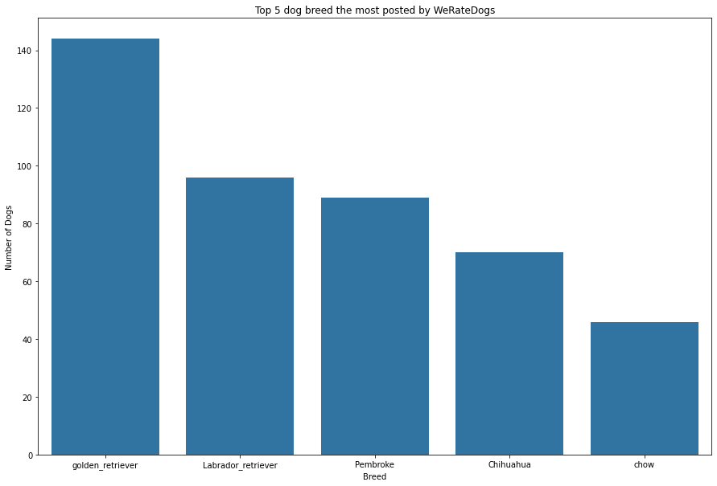

```python
#Plot finding
plt.figure(figsize = [15, 10])
base_color = sb.color_palette()[0]
breed_order = archive_clean.breed.value_counts()[:5].index

sb.countplot(data=archive_clean, x='breed', color=base_color, order=breed_order)

plt.xlabel('Breed')
plt.ylabel('Number of Dogs')
plt.title('Top 5 dog breed the most posted by WeRateDogs');
```

#### Answer 1:

> The most posted dog breed by WeRateDogs is a **Golden Retriever**, with a **Labrador Retriever** coming in as the second most popular breed, then **Pembroke**, **Chihuahua** and **Chow** takes the fifth place

### Question 2 : For this Top 5, which one is the best rated ? the most liked ? the most retweeted ?

```python
# Top 5 breed the most posted
index = archive_clean.breed.value_counts()[:5].index
```

```python
# calculate the mean value of rating, retweet_count and favorite_count
archive_clean.groupby('breed').mean().loc[index, ['rating_numerator', 'retweet_count', 'favorite_count']]
```

|  | rating_numerator | retweet_count | favorite_count |
| --- | --- | --- | --- |
| golden_retriever | 11.750000 | 3151.694444 | 11070.930556 |
| Labrador_retriever | 11.416667 | 3282.968750 | 10827.343750 |
| Pembroke | 11.752809 | 2702.224719 | 10277.651685 |
| Chihuahua | 11.414286 | 2952.257143 | 9421.171429 |
| chow | 11.608696 | 2340.521739 | 8511.673913 |

[output not shown]

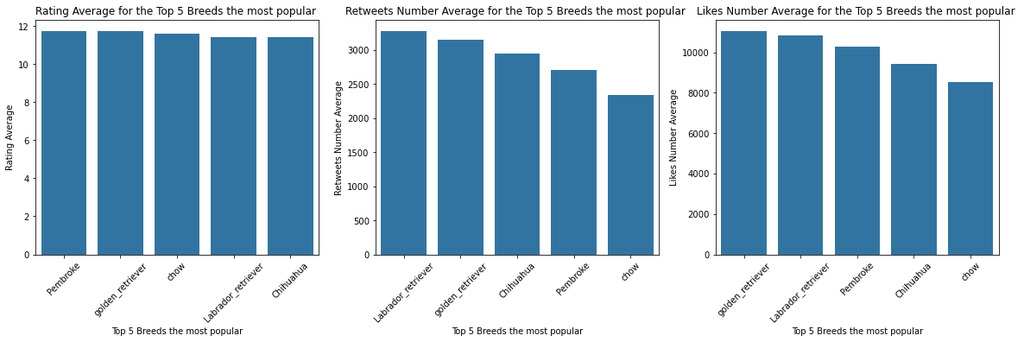

```python
#Plot finding
plt.figure(figsize = [20, 5])
base_color = sb.color_palette()[0]

# The best rated breed
plt.subplot(1, 3, 1)
breed_order = archive_clean.groupby('breed').mean().loc[index, ['rating_numerator']].sort_values('rating_numerator', ascending=False).index
x = archive_clean.breed.value_counts()[:5].index
y = archive_clean.groupby('breed').mean().loc[index, 'rating_numerator']
sb.barplot(x, y, color=base_color, order=breed_order)
plt.xlabel('Top 5 Breeds the most popular')
plt.ylabel('Rating Average')
plt.title('Rating Average for the Top 5 Breeds the most popular ')
plt.xticks(rotation=45)

# The most retweeted breed
plt.subplot(1, 3, 2)
breed_order = archive_clean.groupby('breed').mean().loc[index, ['retweet_count']].sort_values('retweet_count', ascending=False).index
x = archive_clean.breed.value_counts()[:5].index
y = archive_clean.groupby('breed').mean().loc[index, 'retweet_count']
sb.barplot(x, y, color=base_color, order=breed_order)
plt.xlabel('Top 5 Breeds the most popular')
plt.ylabel('Retweets Number Average')
plt.title('Retweets Number Average for the Top 5 Breeds the most popular ')
plt.xticks(rotation=45)

# The most liked breed
plt.subplot(1, 3, 3)
breed_order = archive_clean.groupby('breed').mean().loc[index, ['favorite_count']].sort_values('favorite_count', ascending=False).index
x = archive_clean.breed.value_counts()[:5].index
y = archive_clean.groupby('breed').mean().loc[index, 'favorite_count']
sb.barplot(x, y, color=base_color, order=breed_order)
plt.xlabel('Top 5 Breeds the most popular')
plt.ylabel('Likes Number Average')
plt.title('Likes Number Average for the Top 5 Breeds the most popular ')
plt.xticks(rotation=45)
```

#### Answer 2 :

> For the Top 5 breeds the most popular , we find that :
> - **Pembroke** is the best rated
> - **Labrador Retriever** is the most retweeted
> - **Golden Retriever** is the most liked

### Question 3 : Is the numner of retweet correleted with the number of likes ?

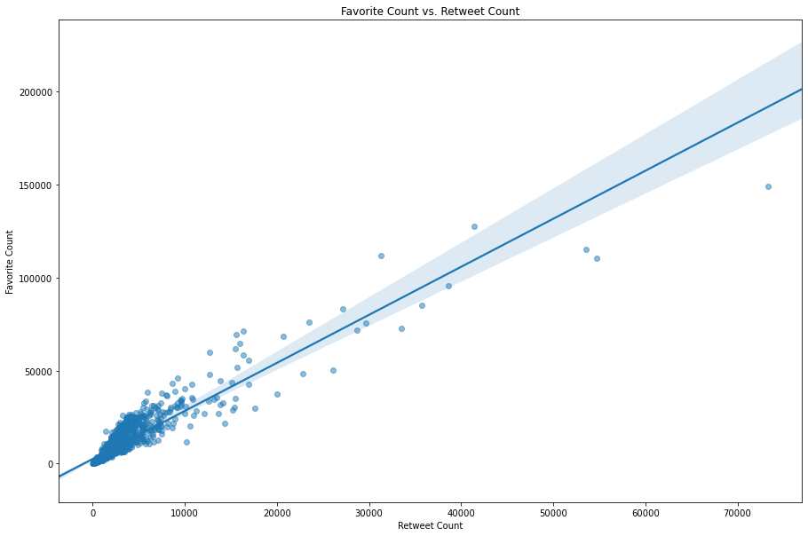

```python
# plot finding
plt.figure(figsize = [15, 10])
sb.regplot(data = archive_clean, x = 'retweet_count', y = 'favorite_count', truncate=False, scatter_kws={'alpha':0.5});
plt.title('Favorite Count vs. Retweet Count');
plt.xlabel('Retweet Count');
plt.ylabel('Favorite Count');
```

```python
# print the correlation coefficient
np.corrcoef(archive_clean.retweet_count, archive_clean.favorite_count)
```

```
array([[1.        , 0.92872319],
       [0.92872319, 1.        ]])
```

#### Answer 3

> **Favorite counts** are correlated with **retweet counts** - this is a strong positive correlation

### Question 4 : Is Rating correlated with Number of Retweets and Number of Likes ?

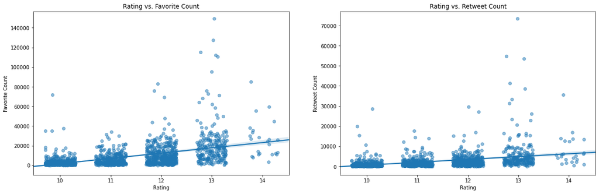

```python
plt.figure(figsize = [20, 6])

# plot Rating vs. Favorite Count
plt.subplot(1, 2, 1)
sb.regplot(data = archive_clean, x = 'rating_numerator', y = 'favorite_count', truncate=False, x_jitter=0.3, scatter_kws={'alpha':0.5});
plt.title('Rating vs. Favorite Count');
plt.xlabel('Rating');
plt.ylabel('Favorite Count');

# plot Rating vs. Retweet Count
plt.subplot(1, 2, 2)
sb.regplot(data = archive_clean, x = 'rating_numerator', y = 'retweet_count', truncate=False, x_jitter=0.3, scatter_kws={'alpha':0.5});
plt.title('Rating vs. Retweet Count');
plt.xlabel('Rating');
plt.ylabel('Retweet Count');
```

```python
# print the correlation coefficient between Rating & Favorite Count
np.corrcoef(archive_clean.rating_numerator, archive_clean.favorite_count)
```

```
array([[1.        , 0.45552969],
       [0.45552969, 1.        ]])
```

```python
# print the correlation coefficient between Rating & Retweet Count
np.corrcoef(archive_clean.rating_numerator, archive_clean.retweet_count)
```

```
array([[1.        , 0.33379289],
       [0.33379289, 1.        ]])
```

#### Answer :

> **Ratings** are moderately correlated with **Number of Retweets** and **Number of Likes** - it is a positive correlation